# JDAC Pulse Survey Results

September 2022

Updated: 2022-10-15

[figure not shown]

## Results and Discussion

### Summary

- The majority of respondents are fulfilled by their work and are satisfied with their DD team and JDAC as a whole. Although the majority of participants felt that their workload was ‘just right’, seven respondents (30%) felt their workload was ‘a bit heavy’.
- Ten respondents (44%) expressed that their wellbeing at work or home was either ‘in a really good place’ or ‘in an ok place’. However, thirteen participants felt slightly less optimistic about their wellbeing - ten (44%) reported there were areas at work that could be improved, while three (13%) were concerned that their wellbeing may be negatively impacted if their experience at work worsened/ remained unchanged.
- Most teams across JDAC felt fairly prepared and adequately supported for their mid-year reviews
- Although ten (63%) respondents expressed that they were having monthly developmental conversations with their line managers, two (13%) noted such conversations occurred less regularly and four (25%) disclosed they had yet to receive one
- Most respondents would like more training and development offers. This highlights the importance of potentially exploring training need gaps across JDAC to develop even more training opportunities

### Monthly Questions

#### Wellbeing at Work and in Life

Fig. 1. Participant Demographics (by Team and Grade)

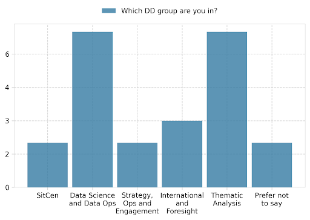

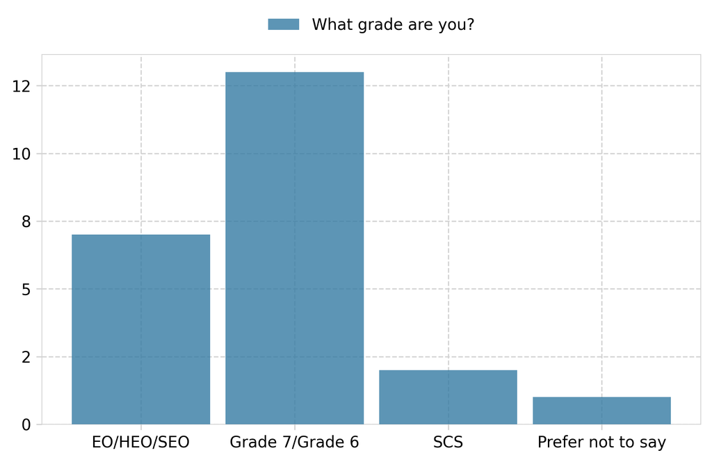

The majority of respondents (87%) expressed they were either ‘in a really good place’ (44%, 10) or ‘in an ok place, but there are things I’d like to improve’ whilst at work respectively (44%, 10) (Fig. 2).

Fig. 2 Wellbeing at Work and in Life

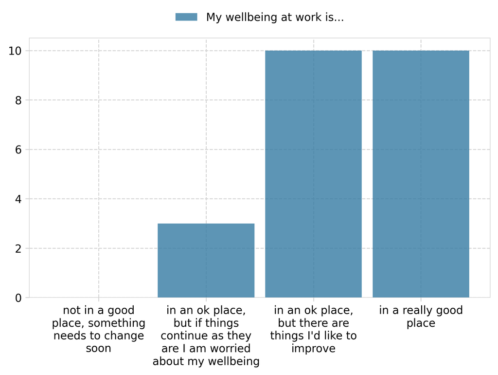

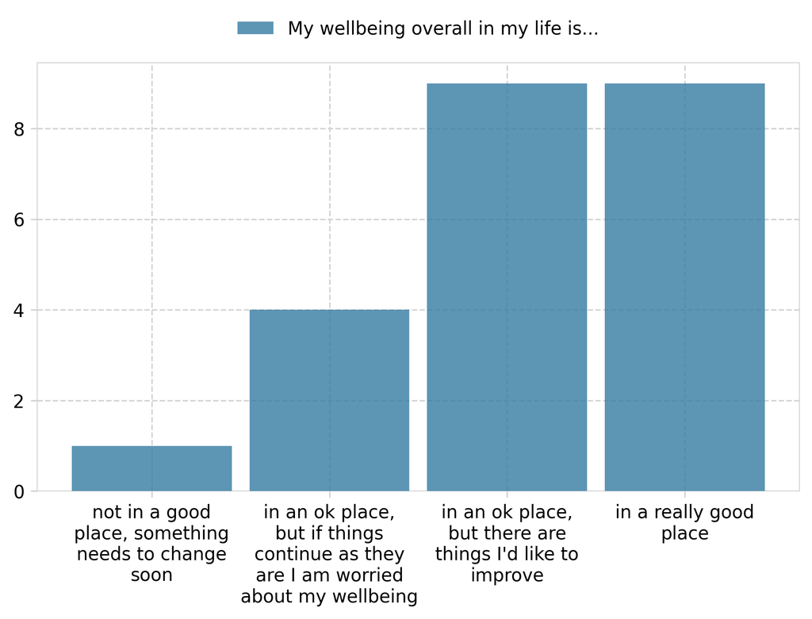

Similarly, most participants (40%, 9) responded that in their personal life, they were either ‘in a really good place’ or ‘in an ok place, but there things I’d like to improve’ respectively. Relatively low numbers (13%) of respondents across JDAC experienced lower mood at work (13%, 3) or in their personal lives (17%, 4).

#### Workload and Work Fulfillment

The majority of respondents (52%, 12) felt that their workload was ‘just right’ (Fig. 3). However, a considerable proportion of respondents (30%, 7) found that their workload was ‘a bit heavy’ (Fig. 3).

Fig. 3 Workload Feelings

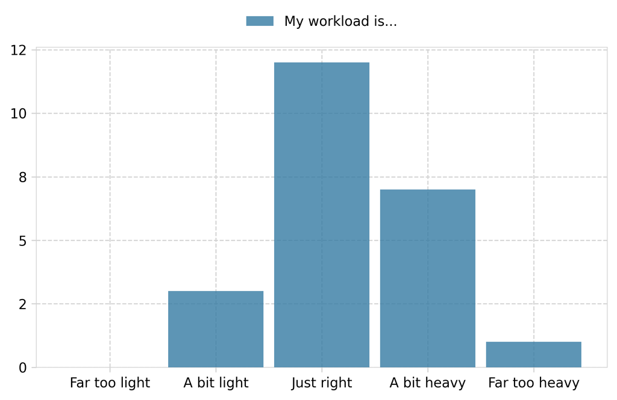

On a scale of 1 to 5, where 1 indicated ‘not at all’ and 5 represented ‘very well’, a median score of 4 was reported for work fulfillment. Most respondents (8) expressed they believed that they their job complemented their interests and skills (Fig. 4).

Fig. 4 Work Fulfillment

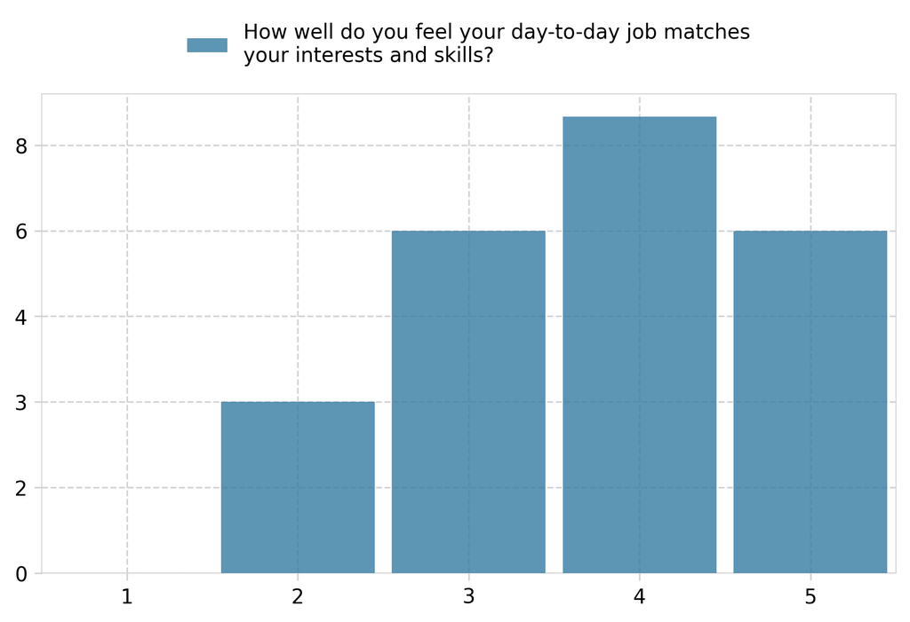

#### Team Effectiveness

The majority of respondents (44%, 10) expressed things were going ‘quite well’ in their DD team and in JDAC as a whole (52%, 12) (Fig. 5).

Fig. 5 Team Effectiveness

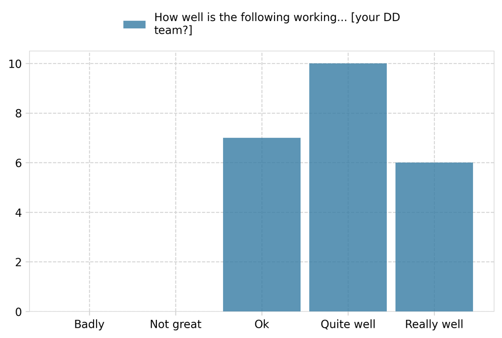

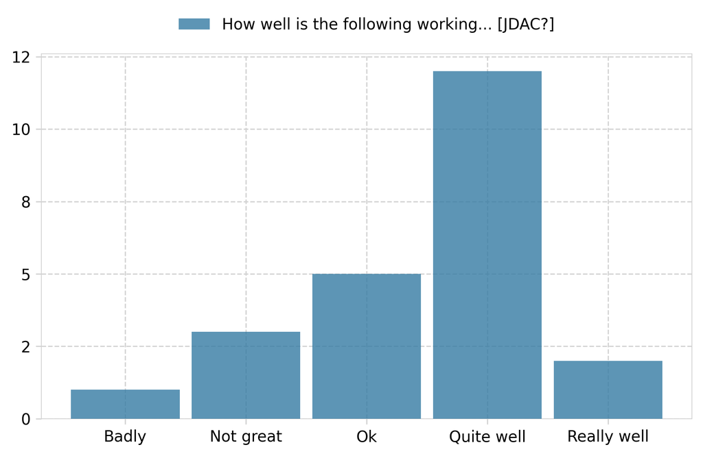

#### Development and Training

The median response of participants reporting they had clearly defined goals was 3 of 5.

Fig. 6 Established Goals

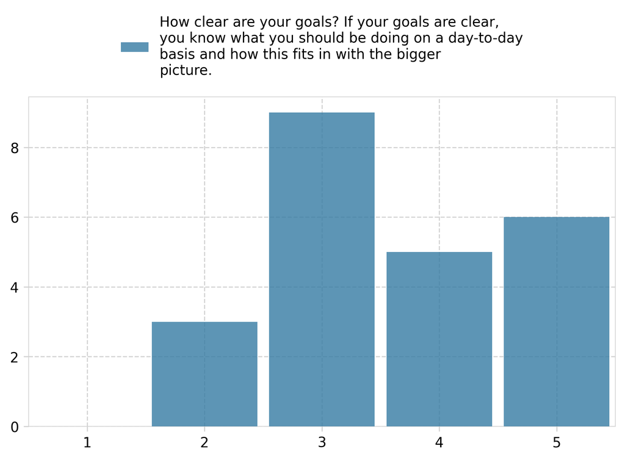

A common theme highlighted by participants included the need for a clearer and unified sense of direction and priorities from the SLT as well as a sense of a common culture across teams to encourage more connection across JDAC.

Fig. 7 Core and Wider Training and Development

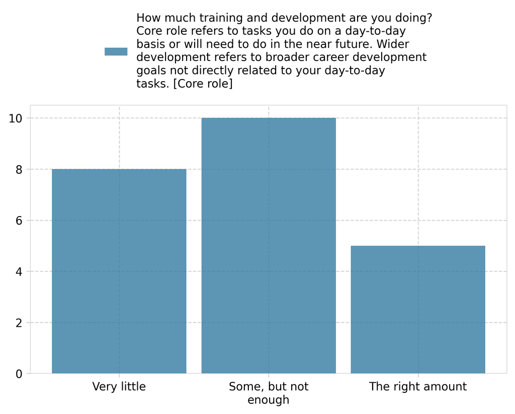

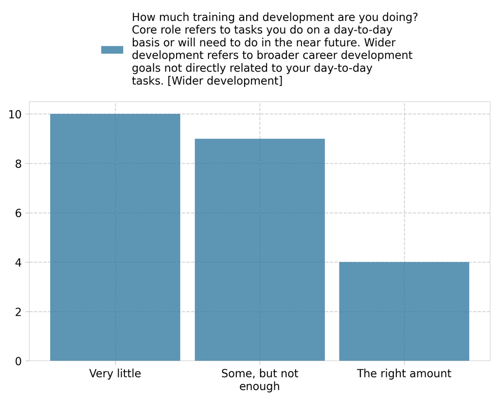

Furthermore, most respondents across JDAC also expressed feeling they had undertaken either ‘very little’ (44%, 10) or ‘some, but not enough’ (40%, 9) wider training and development (Fig. 7). A common theme identified from respondent comments highlighted the importance of exploring training need gaps across JDAC to develop even more effective learning and development offers:

*“L&D!! What do people want to learn? How do we encourage learning as a group?”*

### Wildcard Questions

Of those who are not exempt from completing mid-year reviews, just 16% reported having completed one (Fig. 8).

Fig. 8 Mid-Year Review Completion

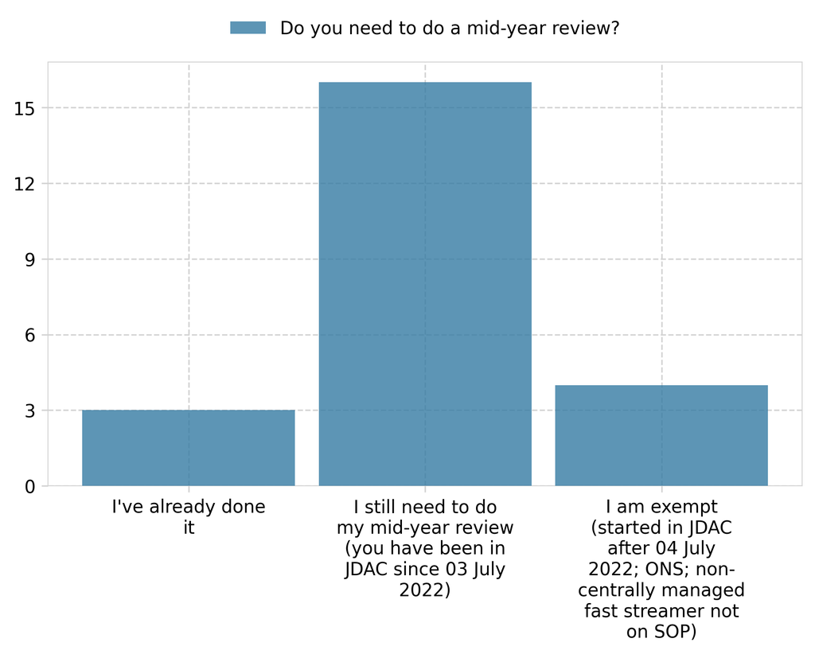

However, as the survey closed on the same day as the mid-year review deadline, it is possible some respondents may have completed their mid-year review shortly before or after the survey deadline despite disclosing non-completion in their earlier response. For this reason, mid-year review completion rates may be subject to change.

Additionally, although six participants did not respond, most of the respondents (71%, 12) who were asked if they knew who to contact for concerns/ questions about the mid-year review process, noted feeling supported.

Furthermore, on a scale of 1 to 5, where 1 represented ‘not at all prepared’ and 5 represented ‘very prepared’, most participants across JDAC felt fairly prepared for their mid-year reviews - the median score of respondents for preparedness was 4 (Fig. 9).

Fig. 9 Mid-Year Review Preparedness

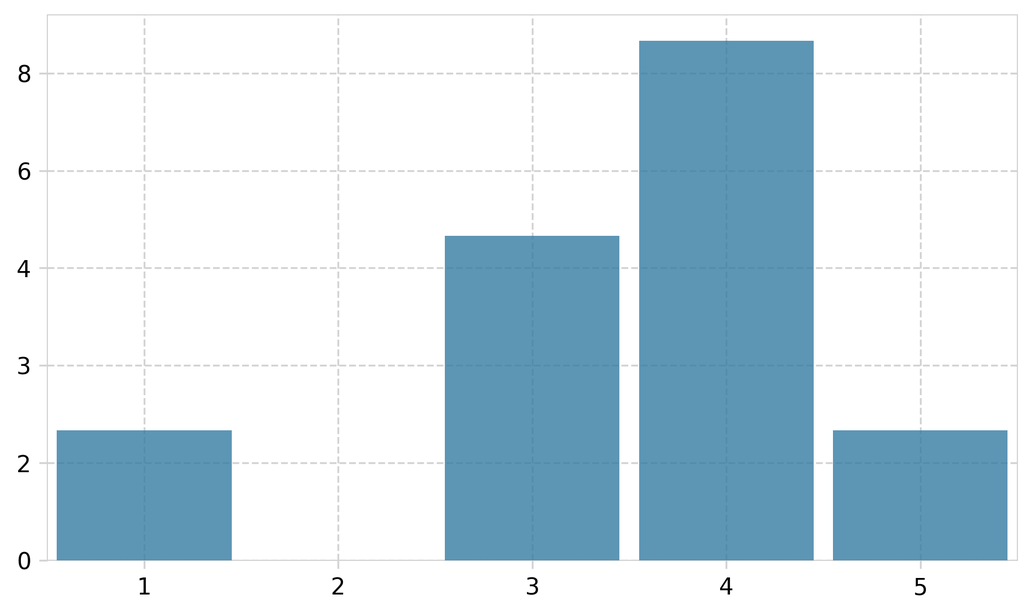

However, although 63% (10) of respondents expressed that they were having monthly developmental conversations with their line managers, 13% (2) noted such conversations occurred less regularly and 25% (4) disclosed they had yet to receive one (Fig. 10).

Fig. 10 Training and Development Planning

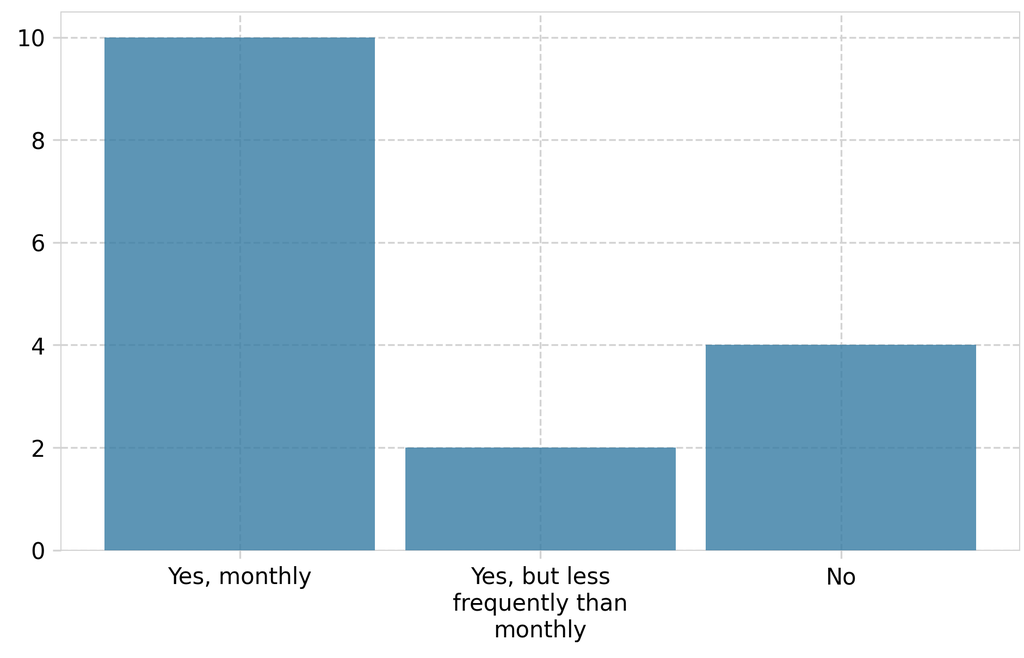

Responses to this question also include those from staff who are exempt from completing a mid-year review.

## Methodology

Each item in the survey was reviewed within the JDAC Pulse Survey Strand so the relevance and appropriateness could be discussed. A pilot test conducted during a Senior Management Team meeting asked volunteers to verbally evaluate items that were not understood. No difficulties were encountered. Minor changes were made to the questions in the final version following the pilot.

The survey consisted of 20 questions and six sections (please refer to Table 1).

| Section | No. of Items | Type of Data | Response Options | Additional Response Options 1 | Additional Response Options 2 | Additional Response Options 3 | Additional Response Options 4 | Additional Response Options 5 | Additional Response Options 6 |
| --- | --- | --- | --- | --- | --- | --- | --- | --- | --- |
| Monthly Questions | 11 | Nominal Scale; Frequency Scale; Semantic Differential Scale; 3-point Likert Scale; 5-point Likert Scale | 1 = not in a good place, something needs to change soon; 2 = in an ok place, but if things continue as they are I am worried about my wellbeing; 3 = in an ok place, but there are things I'd like to im… | 1 = not in a good place, something needs to change soon; 2 = in an ok place, but if things continue as they are I am worried about my wellbeing; 3 = in an ok place, but there are things I'd like to im… | 1 = Far too light; 2 = A bit light; 3 = Just right; 4 = A bit heavy; Far too heavy | 1 = Not at all; 5 = Very well | 1 = Badly; 2 = Not great; 3 = Ok; 4 = Quite well; 5 = Really well | 1 = Very unclear; 5 = Very clear | 1 = Very little; 2 = Some, but not enough; 3 = The right amount |
| Wildcard Question: The Mid-Year Review | 1 | Nominal Scale |  |  |  |  |  |  |  |
| I Have Completed My Mid-Year Review | 3 | Semantic Differential Scale | 1 = Very unhappy; 5 = Very happy | 1 = Very satisfied; 5 = Very satisfied |  |  |  |  |  |
| I Have Not Completed My Mid-Year Review (please skip this section if you have completed a review or are exempt) | 3 | Semantic Differential Scale; Nominal Scale | 1 = Not at all - I have no idea how it works; 5 = Very well - I know exactly what the process is | 1 = Not at all prepared; 5 = Very prepared |  |  |  |  |  |
| I Am Exempt From Doing a Mid-Year Review | 1 | Nominal Scale |  |  |  |  |  |  |  |
| Further Information | 1 |  |  |  |  |  |  |  |  |

Participants who had not responded were contacted via email, team meetings and/ or the group chat and reminded to complete their survey weekly. Data was analysed using RStudio 2022.07.1+554.

## Supplementary Material

### Charts

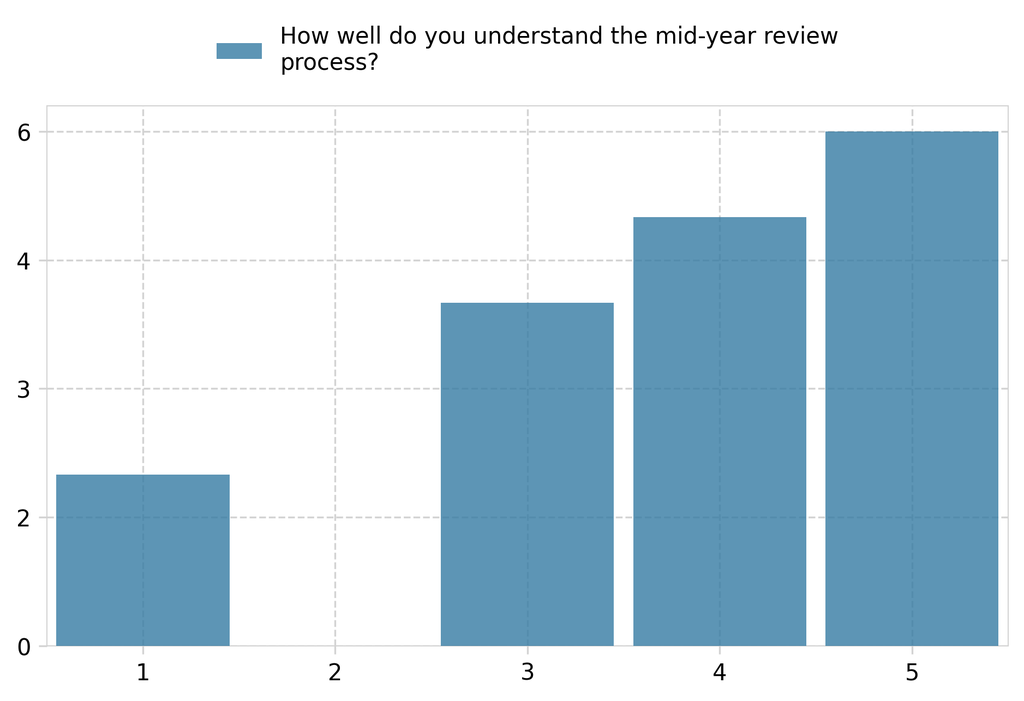

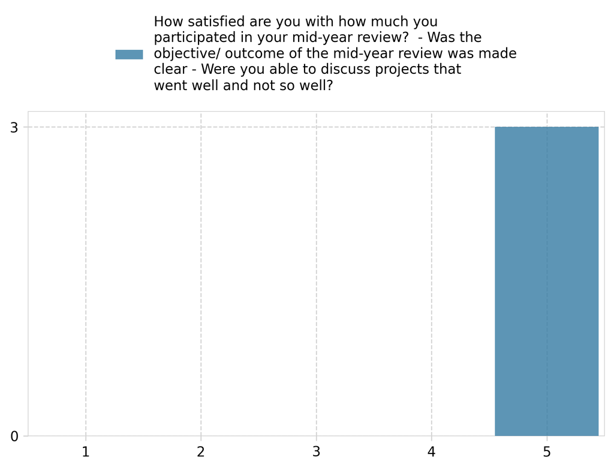

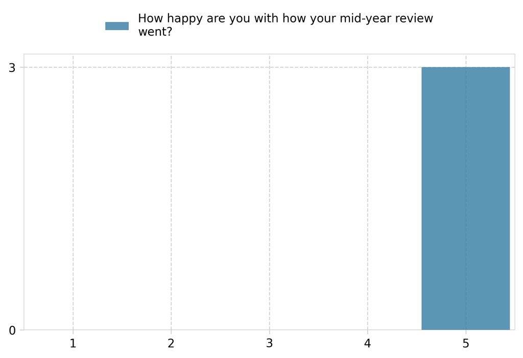

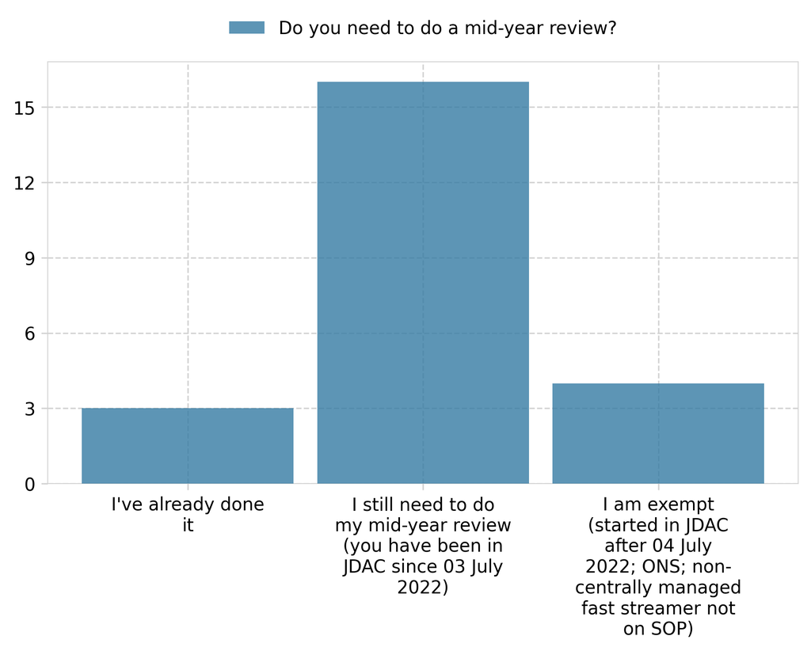

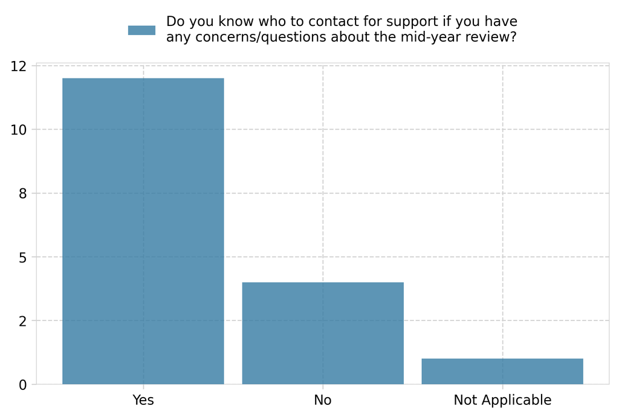

### Tables

Table 2. Wellbeing at Work and in Life

| **Characteristic** | **N = 23**<sup>1</sup> |
| --- | --- |
| Wellbeing at Work |  |
| in a really good place | 10 (43.5) |
| in an ok place, but if things continue as they are I am worried about my wellbeing | 3 (13.0) |
| in an ok place, but there are things I'd like to improve | 10 (43.5) |
| Wellbeing in Life |  |
| in a really good place | 9 (39.1) |
| in an ok place, but there are things I'd like to improve | 9 (39.1) |
| not in a good place, something needs to change soon | 1 (4.3) |
| OK but I am worried about my wellbeing | 4 (17.4) |

Source: Internal data  
<sup>1</sup> n (%)

Table 3. Workload and Work Fulfillment

| **Characteristic** | **N = 23**<sup>1</sup> |
| --- | --- |
| Workload Feelings |  |
| A bit heavy | 7 (30.4) |
| A bit light | 3 (13.0) |
| Far too heavy | 1 (4.3) |
| Just right | 12 (52.2) |
| Work Fulfillment | 4.0 (3.0, 4.5) |

Source: Internal data  
<sup>1</sup> n (%); Median (IQR)

Table 4. Team Effectiveness

| **Characteristic** | **N = 23**<sup>1</sup> |
| --- | --- |
| Team Effectiveness: DD |  |
| Ok | 7 (30.4) |
| Quite well | 10 (43.5) |
| Really well | 6 (26.1) |
| Team Effectiveness: JDAC |  |
| Badly | 1 (4.3) |
| Not great | 3 (13.0) |
| Ok | 5 (21.7) |
| Quite well | 12 (52.2) |
| Really well | 2 (8.7) |

Source: Internal data  
<sup>1</sup> n (%)

Table 5. Development and Training

| **Characteristic** | **N = 23**<sup>1</sup> |
| --- | --- |
| Established Goals | 3.0 (3.0, 4.5) |
| Core Training and Development |  |
| Some, but not enough | 10 (43.5) |
| The right amount | 5 (21.7) |
| Very little | 8 (34.8) |
| Wider Training and Development |  |
| Some, but not enough | 9 (39.1) |
| The right amount | 4 (17.4) |
| Very little | 10 (43.5) |
| Training and Development Planning |  |
| No | 4 (25.0) |
| Yes, but less frequently than monthly | 2 (12.5) |
| Yes, monthly | 10 (62.5) |
| Unknown | 7 |

Source: Internal data  
<sup>1</sup> Median (IQR); n (%)

Table 6. Mid-Year Reviews

| **Characteristic** | **N = 23**<sup>1</sup> |
| --- | --- |
| Eligibility |  |
| I've already done it | 3 (13.0) |
| I am exempt (started in JDAC after 04 July 2022; ONS; non-centrally managed fast streamer not on SOP) | 4 (17.4) |
| I still need to do my mid-year review (you have been in JDAC since 03 July 2022) | 16 (69.6) |
| Supportedness |  |
| No | 4 (23.5) |
| Not Applicable | 1 (5.9) |
| Yes | 12 (70.6) |
| Unknown | 6 |
| Preparedness | 4.0 (3.0, 4.0) |
| Unknown | 6 |

Source: Internal data  
<sup>1</sup> n (%); Median (IQR)